```r
source("practiceQualiLaps.R")
library('ggplot2')
```

```r
suPlot=function(dd,stub=''){
  g=ggplot(dd) + geom_point(aes(x=time,y="Time"),shape=1)
  g=augmented_session_utilisation_chart(aug_laps,3)
  g+ggtitle(paste('F1',stub,'Session Utilisation'))
}
```

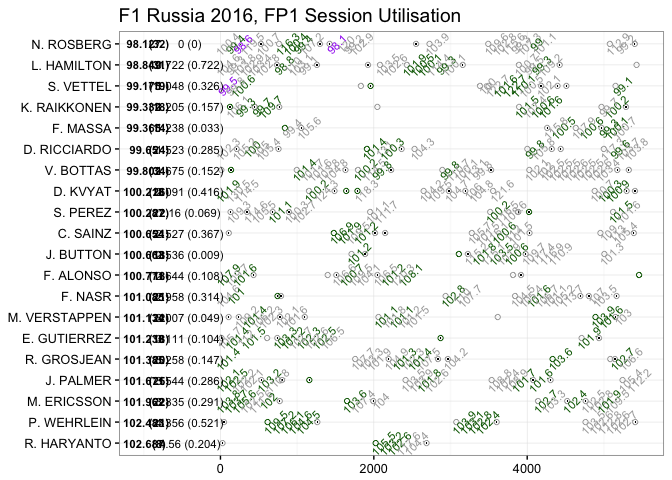

```r
tla_lookup=read.delim("~/Dropbox/various/tla_lookup_2016.txt")

plaps_1= read.csv("~/Dropbox/various/RUS_FP1_2016.csv")
plaps_1=merge(plaps_1,tla_lookup,by.x='number',by.y='CAR')
aug_laps=rawLap_augment_laptimes(plaps_1)
suPlot(aug_laps,'Russia 2016, FP1')
```

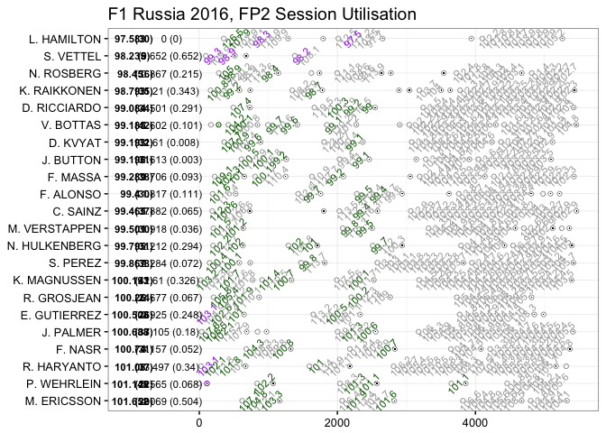

```r
plaps_2= read.csv("~/Dropbox/various/RUS_FP2_2016.csv")
plaps_2=merge(plaps_2,tla_lookup,by.x='number',by.y='CAR')
aug_laps=rawLap_augment_laptimes(plaps_2)
suPlot(aug_laps,'Russia 2016, FP2')
```

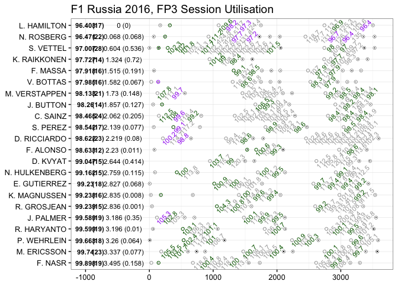

```r
plaps_3= read.csv("~/Dropbox/various/RUS_FP3_2016.csv")
plaps_3=merge(plaps_3,tla_lookup,by.x='number',by.y='CAR')
aug_laps=rawLap_augment_laptimes(plaps_3)
suPlot(aug_laps,'Russia 2016, FP3')
```

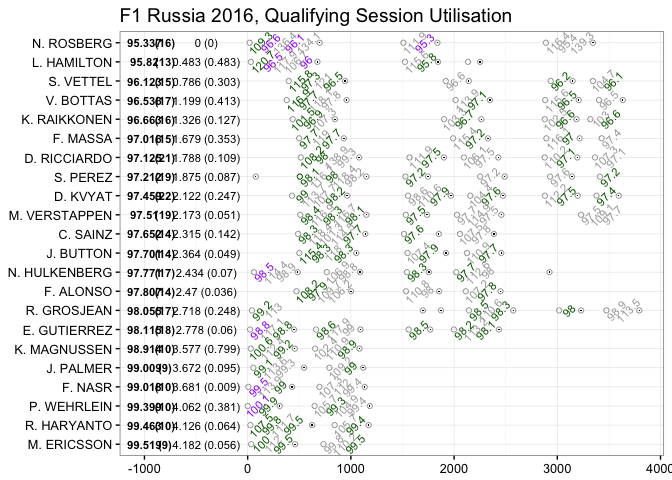

```r
plaps_q= read.csv("~/Dropbox/various/rus16_qualilaptimes.csv")
plaps_q=merge(plaps_q,tla_lookup,by.x='number',by.y='CAR')
aug_laps=rawLap_augment_quali(plaps_q)
suPlot(aug_laps,'Russia 2016, Qualifying')
```

quali_utilisation

g=ggplot(dd) + geom_point(aes(x=time,y=“Time”),shape=1) g=augmented_session_utilisation_chart(aug_laps,3) g+ggtitle(‘F1 Bahrain 2016, Qualifying Session Utilisation’)

st=stintFinder(aug_laps) longruns=longrunFinder(st,aug_laps,4) longrunsplot_min(longruns) longrunsplot_model(longruns,‘lm’,cutoffpc=1.3) longrunsplot_model(longruns[longruns[‘stime’]<96,],‘lm’)

bah_2016_fp2_sectors <- read.delim(“~/tmp/bah_2016_fp2_sectors.tsv”) View(bah_2016_fp2_sectors) dd=bah_2016_fp2_sectors dd[‘time’]=dd[‘BS1’]+dd[‘BS2’]+dd[‘BS3’] g=ggplot(dd) + geom_point(aes(x=time,y=“Time”),shape=1) #Split the drivers into two groups - odd position number and even position number #Use each group as a separate y-axis categorical value g = g + geom_vline(xintercept=92.93,colour=‘grey’,linetype=‘dotted’) g = g + geom_vline(xintercept=93.47, colour=‘grey’,linetype=‘dotted’)

g = g + geom_text(data=subset(dd, subset=(pos %% 2!=0)), aes(x=time, y=“1,3,5,…”, label=paste(TLA,‘(’,TEAM,‘)’,sep=‘’)), size=3) g = g + geom_text(data=subset(dd, subset=(pos %% 2==0)), aes(x=time, y=“2,4,6,…”, label=paste(TLA,’ (‘,TEAM,’)‘,sep=’‘)), size=3) #Tweak the theme g = g + theme_classic() + ylab(NULL) + xlab(’Laptime (s)’) #Add in some intercept lines using the values we used before g=g+coord_flip() g+ggtitle(‘F1 2016 Bahrain FP2’)

g+ggtitle(‘F1 2016 Bahrain FP2’) g = g + geom_vline(xintercept=94.0, col=‘grey’) #Flip the co-ordinates g=g+coord_flip() g